# Speaker comparison

Methods, evidence and conclusions

Dr Massimiliano Canzi

# The David Bieber case

`Did you know:` every bottlenose dolphin develops its own signature whistle. In playback experiments, dolphins still recognised relatives from synthetic whistles that kept only the whistle’s shape, with all voice features removed.

*Source: Janik, Sayigh & Wells (2006), PNAS*

## Boxing Day, Leeds

- On 26 December 2003, two traffic officers stopped a car with false number plates. The driver shot at them and escaped, and PC Ian Broadhurst was killed
- A camera on the police car’s dashboard recorded the gunman’s voice, but not his face

## The known samples

- The suspect, David Bieber, was an American who had lived in Yorkshire for some years under a false identity
- After his arrest he said very little in police interviews, so the police used other known samples: his calls to telephone betting companies

## A mixed accent

Both recordings had the same unusual mixture:

- Rhotic /r/, pronounced in all positions (*right*, *pardon*; *road*, *third*): typical of North American accents, not of Yorkshire
- Typical Yorkshire FACE and GOAT vowels, and Yorkshire terms of address such as *mate* and *love*: not found in American accents

The analyst called it one of the most clear-cut cases he had worked on. Bieber was convicted in December 2004.

## Why it was clear-cut

- The recordings were similar: the same features in both
- The combination was atypical: very few people in the relevant population speak like that
- And the key features were easy to hear: no acoustic measurement was needed

## Today

1. Why comparing voices is hard
2. Which features are ideal, and which features experts analyse
3. Automatic speaker recognition
4. How experts express conclusions: likelihood ratios

This session follows chapter 4 of Leemann et al. (2024).

# Comparing voices

`Did you know:` dolphin mothers change their signature whistle when their calf is with them, using higher maximum frequencies and a wider frequency range: a dolphin version of “motherese”.

*Source: Sayigh et al. (2023), PNAS*

## Forensic speaker comparison

- A questioned recording (an unknown speaker) is compared with a known recording (a suspect, usually from a police interview)
- Questioned recordings: ransom demands, drug deals arranged by phone, a stalker’s voice messages
- Speaker comparison makes up about 70% of forensic speech casework
- In the UK, it was first used in evidence in 1965, and now in around 500 cases a year

## Five approaches

1. Auditory analysis: careful, repeated listening
2. Acoustic analysis: measuring the signal with software
3. Auditory and acoustic analysis combined
4. Automatic speaker recognition (ASR)
5. ASR with human analysis

Combined auditory-acoustic analysis has been the recommended approach since the 1980s. ASR with human analysis is on the rise.

## There is no “voiceprint”

- 1960s–1980s: the idea that spectrograms could be matched by eye, like fingerprints
- The FBI used it for years. But in a survey of 2,000 FBI comparisons, examiners reached a decision in only about a third (Koenig, 1986)
- Speech scientists rejected it: voices vary too much, and recordings differ too much

Acoustic analysis itself is valid. Experts measure specific features across many examples, and allow for known differences between recordings.

## No two samples are identical

- Like a signature, speech is a dynamic movement: no one makes exactly the same movements twice
- Forensic recordings add more variation:
  - speaker: emotion, intoxication, a formal police interview, a taciturn suspect
  - technical: background noise, telephone transmission, reverberation, very short samples
- All of this can change within a single recording

## So: no “match”

- Two recordings will always show some differences and some similarities
- The expert assesses how strongly the evidence supports one explanation over the other, and reports this on a scale

# Ideal features

`Did you know:` dolphins learn their signature whistles. A calf takes a whistle from its environment as a model, then modifies it into a new signal of its own. The identity information lies in the pattern of frequency modulation, independently of voice features.

*Source: Janik & Sayigh (2013), Journal of Comparative Physiology A*

## What makes a feature ideal?

- High between-speaker variation: speakers differ from each other
- Low within-speaker variation: stable across the day, health, situations
- Robust to transmission: survives the telephone
- Robust to disguise and mimicry
- And practical: frequent, easy to measure

## Similarity and typicality

- Similarity: how alike are the questioned and known samples?
- Typicality: how common is the feature in the relevant population?
- The relevant population usually comes from a profile of the questioned speaker: for example, adult men from New Zealand
- Sometimes it is fixed by the case: if CCTV shows three people in the car, the population is the two others

## Similarity and typicality

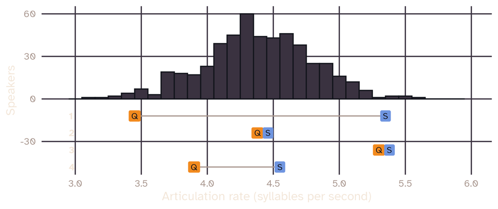

Simulated population of 500 men (mean 4.4 syllables per second). Q: questioned sample, S: suspect sample.

## Reading the four cases

1. Neither similar nor typical, at opposite ends: points towards different speakers
2. Similar but typical: weak support for the same speaker, since many people speak this fast
3. Similar and atypical: relatively strong support for the same speaker
4. Not very similar, both within the typical range: no strong evidence either way

In a real case, articulation rate would be one of many features in the analysis.

## The telephone effect

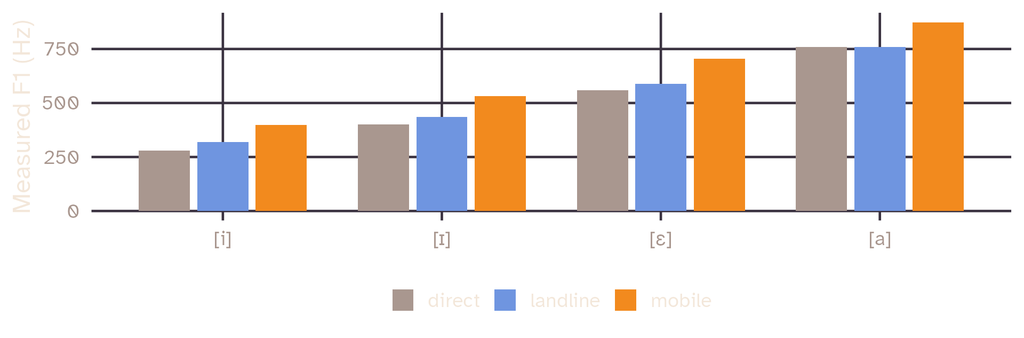

Simulated. Telephones cut energy below about 350 Hz, which raises measured F1, most in low-F1 vowels: up to about 14% on landlines (Künzel, 2001), 29% on average on mobiles (Byrne & Foulkes, 2004).

# Features analysed

`Did you know:` dolphins recognise the signature whistles of former companions after more than 20 years apart: the longest social memory recorded in any non-human species.

*Source: Bruck (2013), Proceedings of the Royal Society B*

## Many layers

Speech is componential: it has layers that are largely independent of each other.

- Segments: vowels, consonants, connected speech processes
- Suprasegmentals: voice quality, f0, intonation, tempo, rhythm
- Higher-level features: words, grammar, discourse markers, pauses
- Non-linguistic features: breathing, laughing, throat clearing

Experts analyse as many as the material allows.

## Vowels

- Almost everyone analyses vowels, because formants depend on both anatomy and accent
- They are usually well-defined, even in poor recordings
- Formants can be measured at the midpoint, or at several points to capture formant dynamics: speakers move between targets in individual ways (McDougall, 2006)

## Formant dynamics

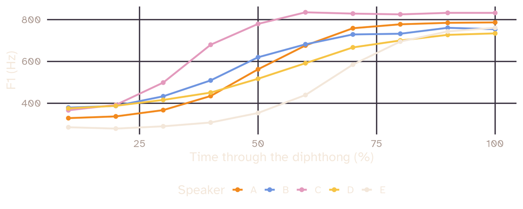

Simulated F1 of five speakers in a close-to-open diphthong, like Thai /ia/. The speakers aim at the same vowels but move between them differently: E starts low and rises late, C rises early.

## Vowels: caveats

- Telephone transmission raises F1, and louder speech and shouting raise formants in general
- So values will not simply “match”: the analyst interprets them, allowing for known sources of difference

## Consonants

Often analysed by ear. In British English cases, for example:

- /h/-dropping: *head* as [ɛd]
- /θ ð/ as [f v] or as stops
- /t/ between vowels: [t], [ɾ] or [ʔ] in *better*
- *-ing* as [ɪŋ] or [ɪn]
- /l/ as [l], [ɫ] or a vowel; /r/ present or absent, and its form

Acoustically: fricatives and nasals carry speaker-specific information, often measured as centre of gravity. But telephones cut off the high frequencies of fricatives.

## Connected speech processes

Shortcuts in fluent speech, used differently by accent and by speaker:

- Assimilation: *handbag* as [ˈhamˌbag]
- Elision: *library* as [ˈlaɪbɹi]
- Epenthesis: *hamster* as [ˈhampstə]

## Voice quality

- Most experts consider it, often with Vocal Profile Analysis (Laver, 1980), usually in simplified versions (San Segundo et al., 2019)
- Vocal tract settings (lips, jaw, tongue, larynx height), muscular tension, phonation type
- Needs substantial training, and ideally at least 40 seconds of speech
- Phonation is affected by stress, exhaustion, alcohol and emotion: a difference does not necessarily mean different speakers

## Fundamental frequency

- Mean, range and standard deviation; at least about one minute of speech for representative values
- Robust to noise, and survives the telephone: f0 can be reconstructed from the harmonics. Harmonics at 500, 600, 700 and 800 Hz imply an f0 of 100 Hz
- But f0 varies a lot within a speaker: louder on the phone, higher in read speech, lower in the morning, higher when agitated
- Most useful for eliminating suspects, and easy to explain to a court

## f0 in a population

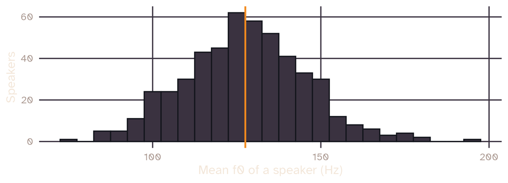

Simulated. In the real Swiss German data (500 men, spontaneous speech), the median is 126 Hz and the range 81–197 Hz (Hedegard et al., 2023). Data like these let us judge typicality.

## Tempo and rhythm

- Articulation rate varies less within a speaker than speaking rate
- But research data often come from students. In UK police interviews, suspects sometimes read a statement prepared by their lawyers: often slower and less fluent than their spontaneous speech
- Rhythm: the percentage of vocalic intervals (%V) is speaker-specific and robust to speaking style (Leemann, Kolly & Dellwo, 2014)

## Higher-level features

- Pausing is speaker-specific and fairly stable
- Filled pauses (*uh*, *um*): how often, and their acoustics. Their acoustics discriminate speakers well, especially *um* (Hughes, Wood & Foulkes, 2016)
- Tag questions (*innit?*, *right?*), discourse markers (*like*), ways of greeting or answering the phone
- Probably below the level of consciousness, so hard to disguise

# Automatic speaker recognition

`Did you know:` dolphins can address each other. Wild dolphins called back when they heard a copy of their own signature whistle, but not when they heard other whistles: they use learned vocal labels, much like names.

*Source: King & Janik (2013), PNAS*

## How ASR works

1. Pre-processing: resampling, voice activity detection
2. Feature extraction: usually mel frequency cepstral coefficients (MFCCs)
3. Speaker modelling: today, x-vectors from deep neural networks
4. Comparison of the questioned and known models: a score
5. Score interpretation: converting the score into a likelihood ratio, against a model of the relevant population

## MFCCs

- Not phonetic features like f0 or formants, but compact descriptions of the whole spectrum, peaks and troughs
- The mel scale warps frequency like human hearing: finer at low frequencies
- Taken from short windows (20–30 ms), 10–20 coefficients every 10 ms or so: thousands per recording
- The resulting speaker model is sometimes called a “voiceprint”, with a different meaning from the 1960s term

## Strengths

- More objective, though humans still choose the recordings, settings and population
- Replicable: same material and settings, same result
- Fast: seconds instead of hours
- In a 2019 survey, over 40% of practitioners used ASR (Gold & French, 2019)

## Weaknesses

- Needs at least about 10 seconds of net speech per sample; 30 seconds is better
- Channel mismatch: a telephone call against a recording in a reverberant interview room. Newer x-vector systems cope better
- A black box: results cannot be explained in terms a court understands, such as pitch or accent
- When the book was written, ASR had not yet been admitted in evidence in UK courts

Most reputable labs use a human-machine team: ASR plus phonetic analysis, which can catch differences such as accent that ASR might miss.

## Discussion

An ASR system gives strong support for the same speaker. Your phonetic analysis finds that the questioned speaker has a northern English accent and the suspect a southern one.

How should the report deal with the disagreement? Would your answer change if the court had never heard ASR evidence before?

# Likelihood ratios

`Did you know:` researchers in Sarasota Bay, Florida, have recorded the signature whistles of the same wild dolphin community since 1975: a catalogue of more than 250 individuals, which makes long-term studies of identity possible.

*Source: King et al. (2013), Proceedings of the Royal Society B*

## From “match” to strength of evidence

- Before the 1990s, conclusions were often binary (the same speaker, or not). This is now widely rejected, because no speech feature is unique or invariant
- Most practitioners now express conclusions as likelihood ratios (LRs), as recommended for forensic science generally (AFSP, 2009)

## Crossing the road

- Evidence: the traffic you see, its speed, the width of the road
- Two hypotheses: I can cross safely; I cannot
- You weigh how likely the evidence is under each, and cross if the first clearly outweighs the second
- Other information also matters: how much of a hurry you are in, your experience of this road

This is Bayesian reasoning, which forensic science applies formally.

## The likelihood ratio

LR = p(evidence | same speaker) / p(evidence | different speakers)

- How likely is the evidence if the samples come from the same speaker, relative to different speakers?
- LR above 1: support for the same-speaker hypothesis. Below 1: for the different-speaker hypothesis
- An LR of 100: the evidence is 100 times more likely under one hypothesis than the other

## A shoe print

- A size 13 print at a crime scene. The suspect wears size 13: similarity = 1
- About 5% of men wear size 13: typicality = 0.05
- LR = 1 / 0.05 = 20: the print is 20 times more likely if the suspect left it than if a random man did

The LR does not say whether the suspect left the print. That decision belongs to the court, which weighs all the evidence.

## Computing an LR

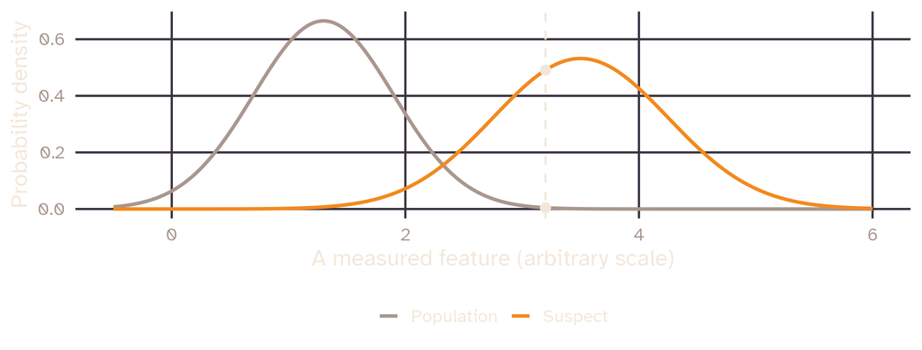

Hypothetical data. The questioned value (dashed): 0.491 / 0.0044 = LR of 111, log<sub>10</sub>LR = 2.05.

## Which population?

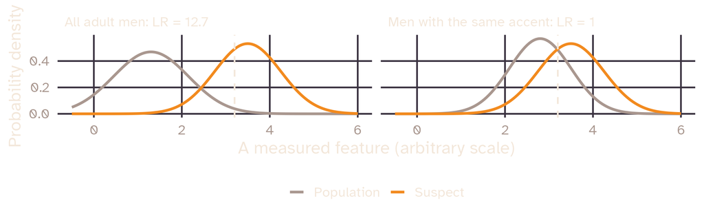

Hypothetical data. The same suspect and the same questioned value (dashed), against two definitions of the relevant population. A value that is unusual among all adult men can be common among men with the same accent, and the LR shrinks. Who belongs in the population depends on the facts of the case.

## The verbal scale

| Support for the same-speaker hypothesis | LR | log<sub>10</sub>LR |
| --- | --- | --- |
| extremely strong | > 1,000,000 | > 6 |
| very strong | 10,000–1,000,000 | 4–6 |
| strong | 1,000–10,000 | 3–4 |
| moderately strong | 100–1,000 | 2–3 |
| moderate | 10–100 | 1–2 |
| weak | 1–10 | 0–1 |
| inconclusive | 1 | 0 |

The scale continues symmetrically below 1 for the different-speaker hypothesis (AFSP, 2009). Some practitioners use slightly different boundaries at the top of the scale.

## Why logarithms?

- An LR of 100 is as strong as an LR of 0.01, in the other direction
- Large numbers and tiny fractions are hard to compare
- log<sub>10</sub> makes the scale symmetrical around 0: 1,000,000 becomes 6, 0.000001 becomes −6
- Our example: LR 111 → log<sub>10</sub>LR 2.05 → moderately strong support for the same speaker

## A real case

- Australia, 2012–2013: fraud calls to a financial institution were recorded (Enzinger, Morrison & Ochoa, 2016)
- Relevant population: adult male speakers of Australian English, from a corpus
- The questioned call had noise, reverberation and landline transmission. The experts degraded the corpus recordings to match
- Result: LR = 3,287 (log<sub>10</sub>LR = 3.52): strong support for the same-speaker hypothesis

## Discussion

Is an LR of 3,287 big or small?

- What else would you need to know before deciding whether the suspect made the calls?
- Who should make that decision?

## Exercises

For the practical sessions (book activities 4A and 4B):

- Measure f0 and articulation rate in one questioned and five suspect speakers. Which suspect is most similar, and is the similarity typical?
- Compare a telephone call with a police interview recording, and write a short report on at least four features

## Summary

- Speaker comparison: a questioned recording against a known one; about 70% of casework
- There is no voiceprint, and no two samples are identical
- Experts assess similarity and typicality in a relevant population
- Many features, each with strengths and weaknesses: formants, consonants, voice quality, f0, tempo, rhythm, pauses
- ASR is fast and replicable, but needs good material and is hard to explain
- Conclusions are expressed as likelihood ratios, which give the strength of the evidence and leave the verdict to the court

## References

- AFSP [Association of Forensic Science Providers] (2009). Standards for the formulation of evaluative forensic science expert opinion. *Science & Justice*, 49(3), 161–164.
- Byrne, C., & Foulkes, P. (2004). The “mobile phone effect” on vowel formants. *International Journal of Speech, Language and the Law*, 11(1), 83–102. https://doi.org/10.1558/ijsll.v11i1.83
- Enzinger, E., Morrison, G. S., & Ochoa, F. (2016). A demonstration of the application of the new paradigm for the evaluation of forensic evidence under conditions reflecting those of a real forensic-voice-comparison case. *Science & Justice*, 56(1), 42–57. https://doi.org/10.1016/j.scijus.2015.06.005
- Gold, E., & French, P. (2019). International practices in forensic speaker comparisons: Second survey. *International Journal of Speech, Language and the Law*, 26(1), 1–20.
- Hedegard, H., Fröhlich, A., Tomaschek, F., Steiner, C., & Leemann, A. (2023). Filling the population statistics gap: Swiss German reference data on F0 and speech tempo for forensic contexts. *Proceedings of Interspeech 2023*, 2558–2562. https://doi.org/10.21437/Interspeech.2023-1042
- Hughes, V., Wood, S., & Foulkes, P. (2016). Strength of forensic voice comparison evidence from the acoustics of filled pauses. *International Journal of Speech, Language and the Law*, 23(1), 99–132. https://doi.org/10.1558/ijsll.v23i1.29874
- Koenig, B. E. (1986). Spectrographic voice identification: A forensic survey. *Journal of the Acoustical Society of America*, 79, 2088–2090.

## References

- Künzel, H. J. (2001). Beware of the “telephone effect”: The influence of telephone transmission on the measurement of formant frequencies. *Forensic Linguistics*, 8(1), 80–99. https://doi.org/10.1558/ijsll.v8i1.80
- Laver, J. (1980). *The phonetic description of voice quality*. Cambridge University Press.
- Leemann, A., Kolly, M.-J., & Dellwo, V. (2014). Speaker-individuality in suprasegmental temporal features: Implications for forensic voice comparison. *Forensic Science International*, 238, 59–67. https://doi.org/10.1016/j.forsciint.2014.02.019
- Leemann, A., Perkins, R., Sullivan Buker, G., & Foulkes, P. (2024). *An Introduction to Forensic Phonetics and Forensic Linguistics*. Routledge. Chapter 4.
- McDougall, K. (2006). Dynamic features of speech and the characterization of speakers: Toward a new approach using formant frequencies. *International Journal of Speech, Language and the Law*, 13(1), 89–126. https://doi.org/10.1558/ijsll.v13i1.89
- San Segundo, E., Foulkes, P., French, P., Harrison, P., Hughes, V., & Kavanagh, C. (2019). The use of the Vocal Profile Analysis for speaker characterization: Methodological proposals. *Journal of the International Phonetic Association*, 49(3), 353–380. https://doi.org/10.1017/S0025100318000130

## Sources of the animal facts

- Bruck, J. N. (2013). Decades-long social memory in bottlenose dolphins. *Proceedings of the Royal Society B*, 280(1768), 20131726. https://doi.org/10.1098/rspb.2013.1726
- Janik, V. M., & Sayigh, L. S. (2013). Communication in bottlenose dolphins: 50 years of signature whistle research. *Journal of Comparative Physiology A*, 199(6), 479–489. https://doi.org/10.1007/s00359-013-0817-7
- Janik, V. M., Sayigh, L. S., & Wells, R. S. (2006). Signature whistle shape conveys identity information to bottlenose dolphins. *PNAS*, 103(21), 8293–8297. https://doi.org/10.1073/pnas.0509918103
- King, S. L., Sayigh, L. S., Wells, R. S., Fellner, W., & Janik, V. M. (2013). Vocal copying of individually distinctive signature whistles in bottlenose dolphins. *Proceedings of the Royal Society B*, 280, 20130053. https://doi.org/10.1098/rspb.2013.0053
- King, S. L., & Janik, V. M. (2013). Bottlenose dolphins can use learned vocal labels to address each other. *PNAS*, 110(32), 13216–13221. https://doi.org/10.1073/pnas.1304459110
- Sayigh, L. S., El Haddad, N., Tyack, P. L., Janik, V. M., Wells, R. S., & Jensen, F. H. (2023). Bottlenose dolphin mothers modify signature whistles in the presence of their own calves. *PNAS*, 120(27), e2300262120. https://doi.org/10.1073/pnas.2300262120

## Slides and code

[figure not shown]

These slides

mcanzi.de/ws27_fss/04_speaker_comparison.html

Code and all sessions

github.com/mcanzi/ws27_fss